# Background maps in R

In this tutorial we will see how basic tweaks can make maps more readable and attractive, focussing on the addition of basemaps using the ggmap package. We assume little background knowledge of graphics in R, so begin with a basic graph in R's basic graphics package. Then we will move on to the graphically superiour ggplot/ggmap approach, to show how maps can be built as layers. It is recommended that the excellent RStudio program is used to work through this tutorial, although any will do. If you would like to improve this tutorial, please see the project's [github page](https://github.com/Robinlovelace/Creating-maps-in-R/).

## Introduction: tweaking graphics in R

R has very powerful graphical functionality, but a reputation for being fiddly if you aim to create beautiful images, rather than the sparse yet functional base graphics such as:

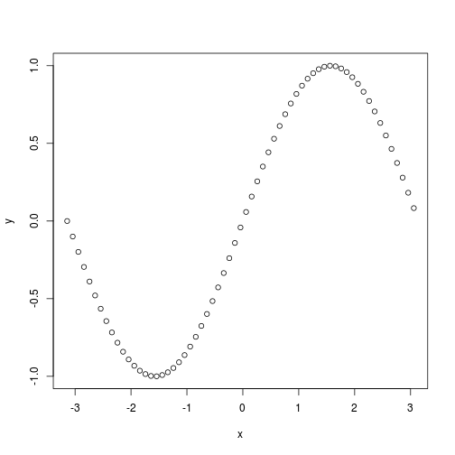

```r
x <- seq(from = -pi, to = pi, by = 0.1)
y <- sin(x)
plot(x, y)
```

It is quite easy to tweak the base graphics, with a few extra lines of code:

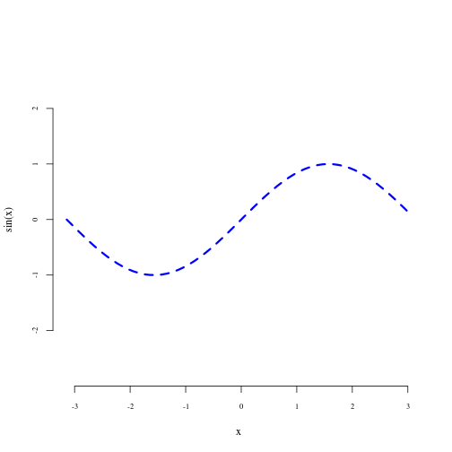

```r
par(family = "serif", font = 5)
plot(x, y, type = "line", col = "blue",
     cex.axis = 0.7, # make axis labels smaller
     ylab = "sin(x)",
     lty = 2, # make the line dotted
     lwd = 3, # make line thicker
     bty = "n", # remove the bounding box
     asp = 1
     )
```

```r
dev.off() # this resets the plot options
```

Although we will be using the more recent ggplot package, which works differently from R's base graphics, the principles will be the same: you start with a basic representation of your data and add further details and optional bells and whistles as you proceed.

## Downloading and unzipping the files

Before proceeding, we first need some geographical data, ready for plotting. R can handle almost any geographical data you through at it, provided the appropriate packages are installed. You can load data that's already on your computer; we assume you have no geographical data and download directly from the internet.

You can download the files outside of R using a browser or any other method. Because R has its own functions for downloading and unzipping files, and it's fun to see what else R can do beyond analysing and plotting data, we will download the files directly from the R command line.

```r
download.file(url = "http://spatialanalysis.co.uk/wp-content/uploads/2010/09/London_Sport.zip",
    destfile = "London_Sport.zip")  # download file from the internet

list.files()  # shows what's in your working director - should include zip file
```

```
##  [1] "figure"                         "ggmapTemp.png"
##  [3] "Intro-2-R.Rproj"                "joining-clipping.html"
##  [5] "joining-clipping.md"            "joining-clipping.Rmd"
##  [7] "london_sport.dbf"               "london_sport.prj"
##  [9] "london_sport.sbn"               "london_sport.sbx"
## [11] "london_sport.shp"               "london_sport.shx"
## [13] "London_Sport.zip"               "mps-recordedcrime-borough.csv"
## [15] "mps-recordedcrime-borough.csve" "overviews.html"
## [17] "overviews.md"                   "overviews.Rmd"
## [19] "README.md"
```

```r
unzip("London_Sport.zip")  # unzip the zip file
list.files()  # should have .shp file added
```

```
##  [1] "figure"                         "ggmapTemp.png"
##  [3] "Intro-2-R.Rproj"                "joining-clipping.html"
##  [5] "joining-clipping.md"            "joining-clipping.Rmd"
##  [7] "london_sport.dbf"               "london_sport.prj"
##  [9] "london_sport.sbn"               "london_sport.sbx"
## [11] "london_sport.shp"               "london_sport.shx"
## [13] "London_Sport.zip"               "mps-recordedcrime-borough.csv"
## [15] "mps-recordedcrime-borough.csve" "overviews.html"
## [17] "overviews.md"                   "overviews.Rmd"
## [19] "README.md"
```

## Installing geographical packages

At present although we have the data files, there is very little we can do with them because geographical functions are lacking from R's base install. Therefore we need to install them. It is important to think carefully about what packages will be needed in R for a given project and ensure they are loaded at the right time.

To see what is currently installed, type the following:

```r
search()
```

```
##  [1] ".GlobalEnv"        "package:knitr"     "package:graphics"
##  [4] "package:grDevices" "package:utils"     "package:datasets"
##  [7] "package:ggplot2"   "package:foreign"   "package:stats"
## [10] "package:methods"   "Autoloads"         "package:base"
```

As you can see, there are already multiple packages in the base installation. For plotting basemaps and geographical analysis more generally, however, we need more:

```r
SpatialPolygonsDataFrame
```

```
## Error: object 'SpatialPolygonsDataFrame' not found
```

```r
# install.packages('rgeos', 'sp') # uncomment this line if rgeos and sp are
# not already on your system
library(rgdal)  # add the powerful rgdal package - note that it automatically loads the sp package also
search()  # see the sp and rgeos packages has now been added
```

```
##  [1] ".GlobalEnv"        "package:rgdal"     "package:sp"
##  [4] "package:knitr"     "package:graphics"  "package:grDevices"
##  [7] "package:utils"     "package:datasets"  "package:ggplot2"
## [10] "package:foreign"   "package:stats"     "package:methods"
## [13] "Autoloads"         "package:base"
```

```r
`?`(`?`(rgdal  # shows you what rgdal can do
))
head(SpatialPolygonsDataFrame)  # now you should see a load of code, telling you the command is available
```

```
##
## 1 function (Sr, data, match.ID = TRUE)
## 2 {
## 3     stopifnot(length(Sr@polygons) == nrow(data))
## 4     if (is.character(match.ID)) {
## 5         row.names(data) = data[, match.ID[1]]
## 6         match.ID = TRUE
```

```r
x = c("ggplot2", "rgeos", "reshape2", "foreign", "plyr")
lapply(x, require, character.only = T)  # the R packages we'll be using
```

```
## rgeos version: 0.2-19, (SVN revision 394)
##  GEOS runtime version: 3.3.8-CAPI-1.7.8
##  Polygon checking: TRUE
##
```

```
## [[1]]
## [1] TRUE
##
## [[2]]
## [1] TRUE
##
## [[3]]
## [1] TRUE
##
## [[4]]
## [1] TRUE
##
## [[5]]
## [1] TRUE
```

(Note: you may want to consider adding a line similar to this to your [.Rprofile file](http://www.statmethods.net/interface/customizing.html), so they load when R initialises, if you use some packages frequently. Some people put a lot of time into [their .Rprofiles!](http://stackoverflow.com/questions/1189759/expert-r-users-whats-in-your-rprofile).)

Packages can be 'unloaded' using the following command:

```r
# detach('package:rgdal', unload=TRUE) Do not run this, unless you want to
# remove rgdal functionality
```

## Basic maps with the sp package

```r
lnd <- readOGR(dsn = ".", "london_sport")
```

[output not shown]

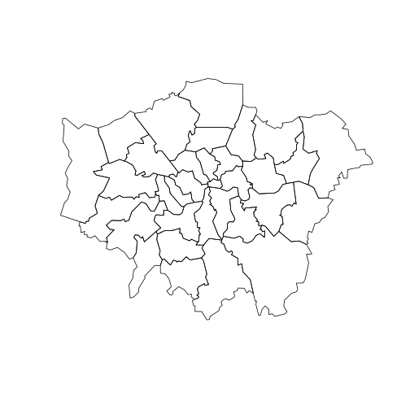

```r
plot(lnd)
```

Note that the plot is quite different from that displayed in the first plot: it has not axes for example. What is going on here? The sp package actually comes with its own plotting command, which is called automatically if the plot is an S4 object. So the actual command that is called is `sp::plot` or “use the plot function from the sp package” in plain English. The following code shows what's going on:

```r
# graphics::plot(lnd) # does not work
sp::plot(lnd)  # does work
```

We can add a few bells and whistles to this plot, but for beautiful maps harnessing the “grammar of graphics”, we need to now transition to the ggplot approach.